# Reproducible Research: Peer Assessment 1

# Reproducible Research: Project 1

## Introduction

This assignment makes use of data from a personal activity monitoring device. This device collects data at 5 minute intervals through out the day. The data consists of two months of data from an anonymous individual collected during the months of October and November, 2012 and include the number of steps taken in 5 minute intervals each day.

## Data

**Dataset** Available here: https://d396qusza40orc.cloudfront.net/repdata%2Fdata%2Factivity.zip

**Fileformat** CSV

17,568 observations

**Variables:**

- *steps*: Number of steps taking in a 5-minute interval (missing values are coded as NA)
- *date*: The date on which the measurement was taken in YYYY-MM-DD format
- *interval*: Identifier for the 5-minute interval in which measurement was taken

## Libraries used

```r
library(knitr)
library(dplyr)
```

```r
library(ggplot2)
```

## Loading and preprocessing the data

```r
rawdata <- read.csv("activity.csv")
activitydata <- rawdata[complete.cases(rawdata),]
```

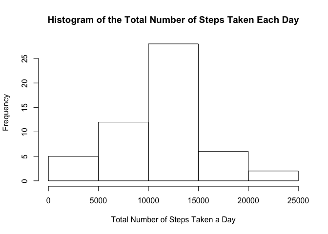

```r
totalStepsPerDay <- aggregate(steps ~ date, activitydata, sum)
hist(totalStepsPerDay$steps, main = "Histogram of the Total Number of Steps Taken Each Day", xlab = "Total Number of Steps Taken a Day")
```

```r
mean(totalStepsPerDay$steps)
```

```
## [1] 10766.19
```

```r
median(totalStepsPerDay$steps)
```

```
## [1] 10765
```

## What is the average daily activity pattern?

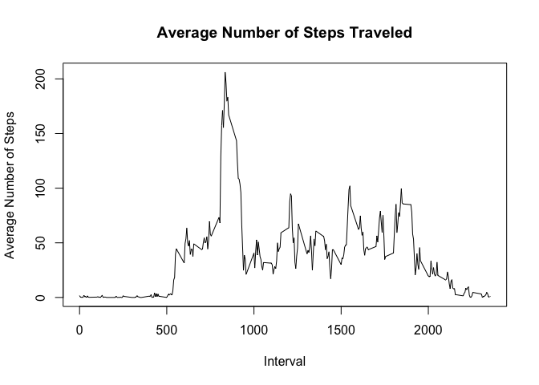

```r
stepsTraveled <- aggregate(steps ~ interval, activitydata, mean)
plot(stepsTraveled$interval, stepsTraveled$steps, type ="l", main = "Average Number of Steps Traveled", xlab = "Interval", ylab = "Average Number of Steps")
```

On average across all the days in the dataset, the 5-minute interval contains the maximum number of steps?

```r
stepsTraveled$interval[which.max(stepsTraveled$steps)]
```

```
## [1] 835
```

## Imputing missing values

There are many days/intervals where there are missing values (coded as `NA`). The presence of missing days may introduce bias into some calculations or summaries of the data.

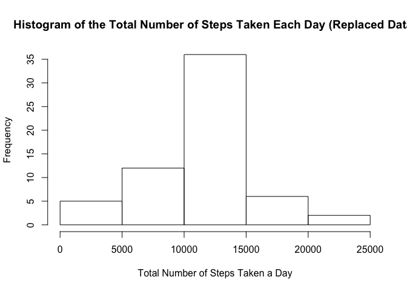

```r
#Missing numbers
totalMissingData <- sum(is.na(rawdata))
##Replacing NA’s with the mean for that 5-minute interval.
replaceddata <- rawdata
for (i in 1:nrow(replaceddata)) {
  if (is.na(replaceddata$steps[i])) {
    interval <- replaceddata[i,"interval"]
    replaceddata[i,"steps"] <- stepsTraveled[(which(stepsTraveled$interval == interval)),"steps"]
  }
}
#Histogram of the total number of steps taken each day
replacedTotalStepsPerDay <- aggregate(steps ~ date, replaceddata, sum)
hist(replacedTotalStepsPerDay$steps, main = "Histogram of the Total Number of Steps Taken Each Day (Replaced Data)", xlab = "Total Number of Steps Taken a Day")
```

```r
#The mean and median total number of steps taken per day
mean(replacedTotalStepsPerDay$steps)
```

```
## [1] 10766.19
```

```r
median(replacedTotalStepsPerDay$steps)
```

```
## [1] 10766.19
```

```r
weekdayMeasures <- weekdays(as.Date(replaceddata$date))
weekdayMeasures[weekdayMeasures %in% c('Saturday','Sunday')] <- "weekend"
weekdayMeasures[weekdayMeasures != "weekend"] <- "weekday"
replaceddata["dayType"] <- weekdayMeasures
```

Now, let’s make a panel plot containing plots of average number of steps taken on weekdays and weekends.

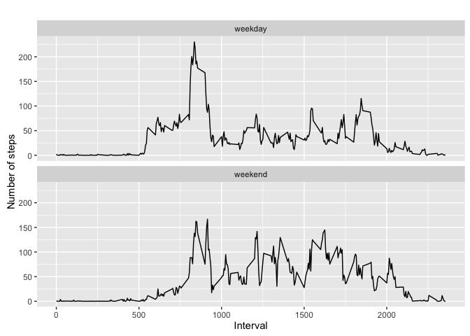

```r
replaceddata$dayType <- as.factor(replaceddata$dayType)
replacedStepTraveled <- aggregate(steps ~ interval + dayType, replaceddata, mean)
qplot(interval, steps,geom=c("line"), data = replacedStepTraveled,xlab = "Interval", ylab = "Number of steps", main = "") +
facet_wrap(~ dayType, ncol = 1)
```